# Bayesian Spatiotemporal Analysis of Ozone Pollution in California

**Author: Jacob Anderson**

**Mentor: Orhun Aydin**

**Research Question**: To what extent does tropospheric ozone exposure explain spatial variation in respiratory mortality across the state of California, and which Bayesian spatial modeling framework — Gaussian BYM2 or Poisson BYM2 — accurately captures this relationship while quantifying uncertainty and identifying high-risk communities?

**The problem**: Respiratory mortality varies substantially across California, and tropospheric ozone—driven by meteorology, emissions, and land use coverage is a major contributor to elevated ozone concentrations. However, accurately quantifying the relationship between ozone exposure and respiratory health remains challenging because both ozone and mortality exhibit strong spatial autocorrelation, measurement uncertainty, and heterogeneity across counties. Remotely sensed ozone estimates introduce additional uncertainty due to unit conversion assumptions and vertical column effects, while traditional regression models cannot properly account for spatial dependence or unequal population structures across counties. As a result, existing approaches risk producing biased effect estimates and misleading conclusions about which communities face the greatest ozone related health risk. A spatial Bayesian framework is needed to appropriately model these uncertainties, capture geographic patterns in exposure and mortality, and provide reliable inference for public health decision making in the state of California.

**Preliminary Tasks: Load libraries, set directories, and credentials**

```r
### Load packages into R environment

library(arcgisbinding)
library(raster)
library(sf)
library(spdep)
library(dplyr)
library(corrplot)
library(performance)
library(Matrix)
library(car)
library(INLA)
library(bayesplot)
library(ggplot2)
library(viridis)
library(RColorBrewer)

arc.check_product()
arc.check_portal()
```

```r
### Important directories for project

### Set the working directory for the project

setwd("C:/Users/ja090/Desktop/Files/JHU/FA25_CAPSTONE/Project/Data")

### Set data directory as R object

data_dir <- "C:/Users/ja090/Desktop/Files/JHU/FA25_CAPSTONE/Project/Data"

### Set geodatabase directory as R object

gdb <- "C:/Users/ja090/Desktop/Files/JHU/FA25_CAPSTONE/Project/Data/Project_Data.gdb"
```

```r
### arc.open function to open the main data frame

fc <- arc.open(file.path(data_dir, "Project_Data.gdb/model_df"))

### arc.select to select the data frame

fc_df <- arc.select(fc)

### arc.data2sf to convert ArcGIS data to sf object

fc_df <- arc.data2sf(fc_df)
```

**Preliminary Tasks: Calculate rates and log offset for Bayesian Spatial Regression**

```r
### Calculate total mortality rate
### Calculate respiratory mortality rate

fc_df <- st_transform(fc_df, 3310) %>%
  mutate(
    mortality_rate = (All_Mortality / TOT_POP) * 1e5,
    resp_mortality_rate = (RespiratoryDeaths / TOT_POP) * 1e5,
    resp_deaths = RespiratoryDeaths,
    log_pop = log(TOT_POP))

### Drop non essential columns

fc_df <- fc_df %>%
  select(where(~ !all(is.na(.))))
```

**Raster data: NASA TEMPO Ozone for 2024 (Converted from DU to ppm)**

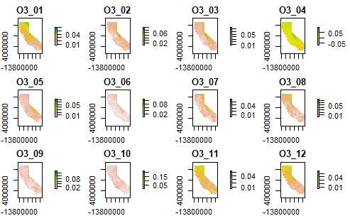

```r
### Read ozone rasters (ppm) and plot for each month in 2024

month_names <- paste0("o3_", ifelse(1:12 < 10, paste0("0", 1:12), 1:12))

### Apply 3x4 grid to plot

par(mfrow = c(3, 4), mar = c(2, 2, 2, 5))

### Loop to display the raster data

for (m in month_names) {
  ras_path <- file.path(gdb, m)
  ras <- arc.open(ras_path)
  ras_o3 <- arc.raster(ras)
  o3_data <- as.raster(ras_o3)
  plot(o3_data, main = toupper(m))
}
```

**Exploratory Analysis of key variables**

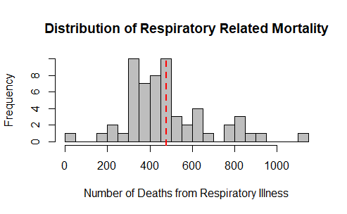

```r
### Histogram for target variable (rate)

hist(fc_df$resp_mortality_rate,
     breaks = 18,
     col = "grey",
     border = "black",
     main = "Distribution of Respiratory Related Mortality",
     xlab = "Number of Deaths from Respiratory Illness",
     ylab = "Frequency")

### Add the mean line

abline(v = mean(fc_df$resp_mortality_rate,
                na.rm = T),
       col = "red",
       lwd = 2,
       lty = 2)
```

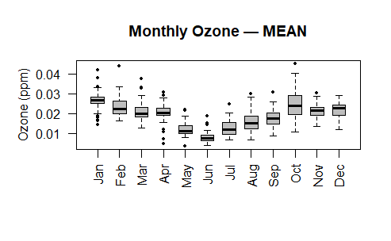

```r
### Box plots for mean and max ozone for each month

mean_cols <- paste0("MEAN_o3_", ifelse(1:12 < 10, paste0("0", 1:12), 1:12))

max_cols <- paste0("MAX_o3_", ifelse(1:12 < 10, paste0("0", 1:12), 1:12))

### Prepare plot area

par(mfrow = c(1, 1), mar = c(6, 5, 4, 2))

### Collect the columns for each month
### Store in list

plot_data <- list()
plot_labels <- character(0)

### Plot the mean ozone concentrations

mean_data <- vector("list", 12)
for (i in 1:12) {
  mean_data[[i]] <- as.numeric(fc_df[[mean_cols[i]]])
}
par(mar = c(6, 5, 4, 2))
boxplot(mean_data,
        names = month.abb,
        las = 2,
        col = "grey",
        outline = T,
        pch = 19,
        cex = 0.6,
        boxwex = 0.6,
        ylab = "Ozone (ppm)",
        main = "Monthly Ozone — MEAN")

### Plot the max ozone concentrations

max_data <- vector("list", 12)
for (i in 1:12) {
  max_data[[i]] <- as.numeric(fc_df[[max_cols[i]]])
}
par(mar = c(6, 5, 4, 2))
```

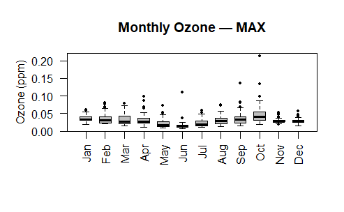

```r
boxplot(max_data,
        names = month.abb,
        las = 2,
        col = "grey",
        outline = T,
        pch = 19,
        cex = 0.6,
        boxwex = 0.6,
        ylab = "Ozone (ppm)",
        main = "Monthly Ozone — MAX")
```

```r
### Test for spatial autocorrelation

### Build neighbors & weights

nb <- poly2nb(as_Spatial(fc_df))
lw <- nb2listw(nb, style = "W", zero.policy = T)

### Global Moran's I: respiratory mortality rate

print("Global Moran's I: Respiratory mortality rate")
```

```
[1] "Global Moran's I: Respiratory mortality rate"
```

```r
g_morans_resp <- moran.test(fc_df$resp_mortality_rate, lw, zero.policy = T)

g_morans_resp_results <- data.frame(
  variable = "resp_mortality_rate",
  morans_I = unname(g_morans_resp$estimate[["Moran I statistic"]]),
  expectation = unname(g_morans_resp$estimate[["Expectation"]]),
  variance = unname(g_morans_resp$estimate[["Variance"]]),
  p_value = g_morans_resp$p.value
)

### Write the results to table

g_morans_resp_results <- write.csv(g_morans_resp_results, file.path(data_dir, "respiratory_morans.csv"), row.names = F)

### Ozone column names

mean_cols <- paste0("MEAN_o3_", ifelse(1:12 < 10, paste0("0", 1:12), 1:12))
max_cols <- paste0("MAX_o3_", ifelse(1:12 < 10, paste0("0", 1:12), 1:12))


### Global Moran's I ozone concentrations (Mean & Max by month)

mi_vals_mean <- numeric(12)
p_vals_mean <- numeric(12)
mi_vals_max <- numeric(12)
p_vals_max <- numeric(12)

print("Global Moran's I: Ozone (monthly MEAN)")
```

```
[1] "Global Moran's I: Ozone (monthly MEAN)"
```

```r
for (i in 1:12) {
  v_mean <- as.numeric(fc_df[[mean_cols[i]]])
  mi_mean <- moran.test(v_mean, lw, zero.policy = T)
  mi_vals_mean[i] <- unname(mi_mean$estimate[["Moran I statistic"]])
  p_vals_mean[i] <- mi_mean$p.value
  print(mi_mean)
}
```

```
    Moran I test under randomisation

data:  v_mean
weights: lw

Moran I statistic standard deviate = 9.2405,
p-value < 2.2e-16
alternative hypothesis: greater
sample estimates:
Moran I statistic       Expectation          Variance
      0.747172721      -0.017543860       0.006848792


    Moran I test under randomisation

data:  v_mean
weights: lw

Moran I statistic standard deviate = 6.7361,
p-value = 8.134e-12
alternative hypothesis: greater
sample estimates:
Moran I statistic       Expectation          Variance
      0.527803400      -0.017543860       0.006554324


    Moran I test under randomisation

data:  v_mean
weights: lw

Moran I statistic standard deviate = 6.2834,
p-value = 1.656e-10
alternative hypothesis: greater
sample estimates:
Moran I statistic       Expectation          Variance
      0.499104452      -0.017543860       0.006760885


    Moran I test under randomisation
```

[output cut: 99 more lines]

```
Moran I statistic       Expectation          Variance
      0.660214671      -0.017543860       0.006943436


    Moran I test under randomisation

data:  v_mean
weights: lw

Moran I statistic standard deviate = 10.458,
p-value < 2.2e-16
alternative hypothesis: greater
sample estimates:
Moran I statistic       Expectation          Variance
      0.863285206      -0.017543860       0.007094056
```

```r
print("Global Moran's I: Ozone (monthly MAX)")
```

```
[1] "Global Moran's I: Ozone (monthly MAX)"
```

```r
for (i in 1:12) {
  v_max <- as.numeric(fc_df[[max_cols[i]]])
  mi_max <- moran.test(v_max, lw, zero.policy = T)
  mi_vals_max[i] <- unname(mi_max$estimate[["Moran I statistic"]])
  p_vals_max[i]  <- mi_max$p.value
  print(mi_max)
}
```

```
    Moran I test under randomisation

data:  v_max
weights: lw

Moran I statistic standard deviate = 6.0935,
p-value = 5.524e-10
alternative hypothesis: greater
sample estimates:
Moran I statistic       Expectation          Variance
      0.492172032      -0.017543860       0.006997206


    Moran I test under randomisation

data:  v_max
weights: lw

Moran I statistic standard deviate = 6.9866,
p-value = 1.408e-12
alternative hypothesis: greater
sample estimates:
Moran I statistic       Expectation          Variance
      0.560507974      -0.017543860       0.006845442


    Moran I test under randomisation

data:  v_max
weights: lw

Moran I statistic standard deviate = 6.1711,
p-value = 3.391e-10
alternative hypothesis: greater
sample estimates:
Moran I statistic       Expectation          Variance
       0.49716157       -0.01754386        0.00695655


    Moran I test under randomisation
```

[output cut: 99 more lines]

```
Moran I statistic       Expectation          Variance
      0.371736848      -0.017543860       0.006662913


    Moran I test under randomisation

data:  v_max
weights: lw

Moran I statistic standard deviate = 5.3554,
p-value = 4.269e-08
alternative hypothesis: greater
sample estimates:
Moran I statistic       Expectation          Variance
       0.42326762       -0.01754386        0.00677525
```

```r
o3_morans_results <- data.frame(
  month = 1:12,
  label = month.abb,
  morans_I_mean = mi_vals_mean,
  p_mean = p_vals_mean,
  morans_I_max = mi_vals_max,
  p_max = p_vals_max
)

### Write the results to table

o3_morans_results <- write.csv(o3_morans_results, file.path(data_dir, "o3_morans.csv"), row.names = F)

### Local Gi*: Respiratory mortality rate

gi_resp <- localG(fc_df$resp_mortality_rate, lw, zero.policy = T)
fc_df$gi_resp <- as.numeric(gi_resp)

### Local Gi*: Ozone (Mean & Max by month)

for (i in 1:12) {
  gi_mean <- localG(as.numeric(fc_df[[mean_cols[i]]]), lw, zero.policy = T)
  gi_max <- localG(as.numeric(fc_df[[max_cols[i]]]),  lw, zero.policy = T)
  fc_df[[paste0("gi_", mean_cols[i])]] <- as.numeric(gi_mean)
  fc_df[[paste0("gi_", max_cols[i])]] <- as.numeric(gi_max)
}

### Gi* class settings

gi_breaks <- c(-Inf, -2.58, -1.96, 1.96, 2.58, Inf)
gi_labs <- c("Cold (99%)","Cold (95%)","Not Sig","Hot (95%)","Hot (99%)")
pal_vals <- c("#084594", "#4292c6", "grey90", "#fb6a4a", "#cb181d"); names(pal_vals) <- gi_labs

### Respiratory mortality Gi* plot

op <- par(no.readonly = T)
par(mar = c(1,1,3,1))
fc_df$gi_class_resp <- cut(fc_df$gi_resp, breaks = gi_breaks, labels = gi_labs)
cols_resp <- pal_vals[as.character(fc_df$gi_class_resp)]
plot(st_geometry(fc_df),
     col = cols_resp,
     border = "grey",
     lwd = 0.01,
     main = "Gi* — Respiratory Death Rate")
legend("bottomleft", fill = pal_vals, legend = names(pal_vals), bty = "n", cex = 0.9)
```

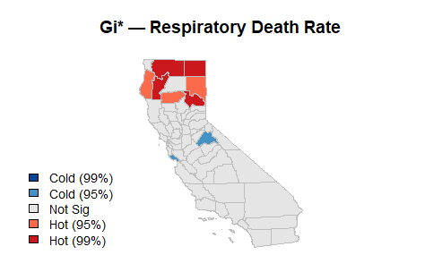

```r
### Build matrices of monthly Gi* z-scores for plot

gi_mean_mat <- cbind(
  as.numeric(fc_df[["gi_MEAN_o3_01"]]), as.numeric(fc_df[["gi_MEAN_o3_02"]]),
  as.numeric(fc_df[["gi_MEAN_o3_03"]]), as.numeric(fc_df[["gi_MEAN_o3_04"]]),
  as.numeric(fc_df[["gi_MEAN_o3_05"]]), as.numeric(fc_df[["gi_MEAN_o3_06"]]),
  as.numeric(fc_df[["gi_MEAN_o3_07"]]), as.numeric(fc_df[["gi_MEAN_o3_08"]]),
  as.numeric(fc_df[["gi_MEAN_o3_09"]]), as.numeric(fc_df[["gi_MEAN_o3_10"]]),
  as.numeric(fc_df[["gi_MEAN_o3_11"]]), as.numeric(fc_df[["gi_MEAN_o3_12"]])
)

gi_max_mat <- cbind(
  as.numeric(fc_df[["gi_MAX_o3_01"]]), as.numeric(fc_df[["gi_MAX_o3_02"]]),
  as.numeric(fc_df[["gi_MAX_o3_03"]]), as.numeric(fc_df[["gi_MAX_o3_04"]]),
  as.numeric(fc_df[["gi_MAX_o3_05"]]), as.numeric(fc_df[["gi_MAX_o3_06"]]),
  as.numeric(fc_df[["gi_MAX_o3_07"]]), as.numeric(fc_df[["gi_MAX_o3_08"]]),
  as.numeric(fc_df[["gi_MAX_o3_09"]]), as.numeric(fc_df[["gi_MAX_o3_10"]]),
  as.numeric(fc_df[["gi_MAX_o3_11"]]), as.numeric(fc_df[["gi_MAX_o3_12"]])
)

### 3×4 Gi* plot: Ozone MEAN

layout(matrix(c( 1,  2,  3,  4, 13,
                 5,  6,  7,  8, 13,
                 9, 10, 11, 12, 13), nrow = 3, byrow = T),
       widths = c(1,1,1,1,0.50), heights = c(1,1,1))

par(mar = c(1,1,3,1))
```

```r
for (i in 1:12) {
  cl <- cut(gi_mean_mat[, i], breaks = gi_breaks, labels = gi_labs)
  cols <- pal_vals[as.character(cl)]
  plot(st_geometry(fc_df), col = cols, border = "grey", lwd = 0.01,
       main = paste0("Gi* Ozone Mean — ", month.abb[i]))
}

par(mar = c(0,0,0,0)); plot.new()
```

```r
legend("center", fill = pal_vals, legend = names(pal_vals), ncol = 1, bty = "n", cex = 1)

layout(1)
```

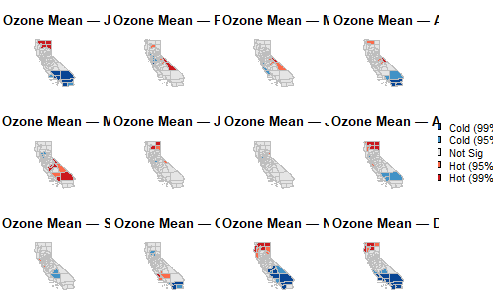

```r
### 3×4 Gi* plot: Ozone MAX

layout(matrix(c( 1,  2,  3,  4, 13,
                 5,  6,  7,  8, 13,
                 9, 10, 11, 12, 13), nrow = 3, byrow = T),
       widths = c(1,1,1,1,0.50), heights = c(1,1,1))

par(mar = c(1,1,3,1))
```

```r
for (i in 1:12) {
  cl   <- cut(gi_max_mat[, i], breaks = gi_breaks, labels = gi_labs)
  cols <- pal_vals[as.character(cl)]
  plot(st_geometry(fc_df), col = cols, border = "grey", lwd = 0.01,
       main = paste0("Gi* Ozone Max — ", month.abb[i]))
}

par(mar = c(0,0,0,0)); plot.new()
```

```r
legend("center", fill = pal_vals, legend = names(pal_vals), ncol = 1, bty = "n", cex = 1)

layout(1)
```

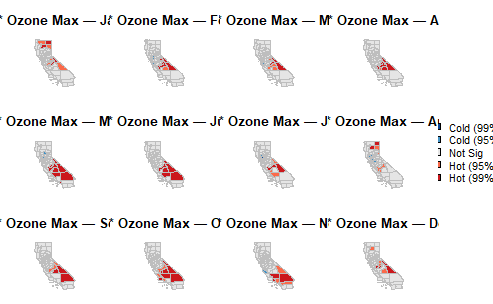

```r
par(op)
```

```r
### Aggregate all ozone measurements (mean & max) to annual estimates for each county

fc_no_geom <- st_drop_geometry(fc_df)

mean_cols <- paste0("MEAN_o3_", ifelse(1:12 < 10, paste0("0", 1:12), 1:12))

max_cols <- paste0("MAX_o3_", ifelse(1:12 < 10, paste0("0", 1:12), 1:12))

fc_no_geom$o3_mean_annual <- rowMeans(fc_no_geom[, mean_cols, drop = F], na.rm = T)

fc_no_geom$o3_max_annual <- do.call(pmax, c(fc_no_geom[, max_cols], na.rm = T))
```

```r
### Collinearity test between covariates

### Group land cover variables

fc_no_geom <- fc_no_geom %>%
  mutate(
    LC_urban = PCT_DEV_OPEN + PCT_DEV_LOW + PCT_DEV_MED + PCT_DEV_HIGH,
    LC_forest = PCT_DEC_FOR + PCT_EVG_FOR + PCT_MX_FOR,
    LC_ag = PCT_CROPLAND + PCT_PASTURE,
    LC_natural = PCT_SHRUB + PCT_GRASSLAND + PCT_BARREN,
    LC_wetlands = PCT_W_WETLAND + PCT_E_WETLAND
  )

### Build a list of the variables

l <- c(
  "LC_urban",
  "LC_forest",
  "LC_ag",
  "LC_natural",
  "LC_wetlands",
  "abnormal_D0",
  "moderate_D1",
  "severe_D2",
  "extreme_D3",
  "MEAN_precip",
  "MEAN_temp",
  "o3_mean_annual",
  "o3_max_annual",
  "PCT_POP_POV",
  "PCT_COM_OVER_90",
  "PCT_POP_DEP_AGE_18_65",
  "PCT_POP_NO_INSUR",
  "resp_mortality_rate"
)

cor_vars <- fc_no_geom[, l, drop = F]

pwise_matrix <- cor(
  cor_vars,
  use = "pairwise.complete.obs")
  round(pwise_matrix, 2)
```

```
                      LC_urban LC_forest LC_ag LC_natural
LC_urban                  1.00     -0.27 -0.08      -0.41
LC_forest                -0.27      1.00 -0.48      -0.33
LC_ag                    -0.08     -0.48  1.00      -0.38
LC_natural               -0.41     -0.33 -0.38       1.00
LC_wetlands              -0.02     -0.22  0.33      -0.18
abnormal_D0               0.27     -0.12  0.19      -0.27
moderate_D1               0.20     -0.27 -0.19       0.31
severe_D2                -0.09     -0.22 -0.05       0.33
extreme_D3               -0.09     -0.22 -0.05       0.33
MEAN_precip              -0.22      0.76 -0.14      -0.48
MEAN_temp                 0.44     -0.52  0.31      -0.10
o3_mean_annual           -0.21      0.55 -0.39      -0.04
o3_max_annual            -0.26     -0.03 -0.30       0.54
PCT_POP_POV              -0.33     -0.07  0.34       0.02
PCT_COM_OVER_90          -0.08      0.00  0.09      -0.03
PCT_POP_DEP_AGE_18_65    -0.56      0.42 -0.14       0.13
PCT_POP_NO_INSUR         -0.36     -0.05  0.06       0.31
resp_mortality_rate      -0.22      0.34 -0.14      -0.05
                      LC_wetlands abnormal_D0 moderate_D1
LC_urban                    -0.02        0.27        0.20
LC_forest                   -0.22       -0.12       -0.27
LC_ag                        0.33        0.19       -0.19
LC_natural                  -0.18       -0.27        0.31
LC_wetlands                  1.00        0.09       -0.10
abnormal_D0                  0.09        1.00       -0.05
moderate_D1                 -0.10       -0.05        1.00
severe_D2                   -0.12       -0.16        0.57
extreme_D3                  -0.13       -0.17        0.56
MEAN_precip                 -0.07        0.10       -0.47
MEAN_temp                    0.07        0.08        0.11
o3_mean_annual               0.06       -0.11       -0.17
o3_max_annual               -0.22       -0.46        0.13
PCT_POP_POV                 -0.02       -0.22        0.14
PCT_COM_OVER_90              0.08        0.18       -0.12
PCT_POP_DEP_AGE_18_65       -0.04       -0.07       -0.08
PCT_POP_NO_INSUR            -0.01       -0.22        0.25
resp_mortality_rate         -0.10       -0.17       -0.01
                      severe_D2 extreme_D3 MEAN_precip
LC_urban                  -0.09      -0.09       -0.22
```

[output cut: 116 more lines]

```
LC_natural                          -0.05
LC_wetlands                         -0.10
abnormal_D0                         -0.17
moderate_D1                         -0.01
severe_D2                           -0.08
extreme_D3                          -0.11
MEAN_precip                          0.51
MEAN_temp                           -0.19
o3_mean_annual                       0.15
o3_max_annual                        0.14
PCT_POP_POV                          0.15
PCT_COM_OVER_90                     -0.03
PCT_POP_DEP_AGE_18_65                0.43
PCT_POP_NO_INSUR                     0.00
resp_mortality_rate                  1.00
```

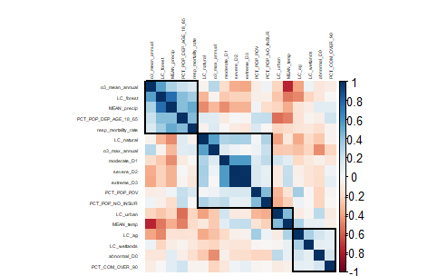

```r
plot_cols <- colorRampPalette(brewer.pal(11, "RdBu"))(200)

corrplot(
  pwise_matrix,
  col = plot_cols,
  method = "color",
  type = "full",
  tl.col = "black",
  tl.cex = 0.3,
  order = "hclust",
  addrect = 4,
  mar = c(0, 0, 1, 0)
)
```

```r
### Variables used in the VIF test

vif_vars <- fc_no_geom[, c(
  "LC_urban",
  "LC_forest",
  "LC_ag",
  "LC_natural",
  "LC_wetlands",
  "abnormal_D0",
  "moderate_D1",
  "severe_D2",
  "MEAN_precip",
  "MEAN_temp",
  "o3_mean_annual",
  "PCT_POP_POV",
  "PCT_COM_OVER_90",
  "PCT_POP_DEP_AGE_18_65",
  "PCT_POP_NO_INSUR"
)]

### Fit a simple linear model to compute VIF

vif_mod <- lm(fc_no_geom$resp_mortality_rate ~ ., data = vif_vars)

### Compute VIF

vif_results <- vif(vif_mod)
print(vif_results)
```

```
             LC_urban             LC_forest
           142.297821            234.521654
                LC_ag            LC_natural
           194.545814            246.375230
          LC_wetlands           abnormal_D0
             5.234084              1.401106
          moderate_D1             severe_D2
             2.435873              2.410083
          MEAN_precip             MEAN_temp
             4.374279              4.108388
       o3_mean_annual           PCT_POP_POV
             3.987666              1.876332
      PCT_COM_OVER_90 PCT_POP_DEP_AGE_18_65
             1.162448              2.177374
     PCT_POP_NO_INSUR
             1.850878
```

```r
### Establish the predictors for Gaussian and Poisson models
### Setting the target variable as new R object

resp_var <- "resp_mortality_rate"

### Setting the predictor variables as new R obect

pred_annual <- c(
  "o3_mean_annual",
  "MEAN_temp",
  "MEAN_precip",
  "severe_D2",
  "LC_urban",
  "PCT_POP_POV",
  "PCT_COM_OVER_90",
  "PCT_POP_DEP_AGE_18_65",
  "PCT_POP_NO_INSUR"
)

pred_annual <- intersect(pred_annual, names(fc_no_geom))

for (nm in unique(c(resp_var, pred_annual))) {
  fc_no_geom[[nm]] <- as.numeric(fc_no_geom[[nm]])
}
```

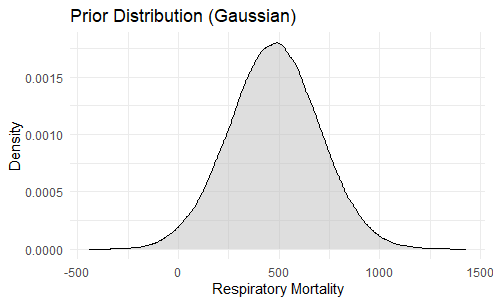

```r
### Sample for prior probability distribution

### Set seed for reproducibility

set.seed(123)

x_raw <- as.matrix(fc_no_geom[, pred_annual, drop = F])

x_scaled <- scale(x_raw)

x <- cbind(Intercept = 1, x_scaled)

y <- as.numeric(fc_no_geom[[resp_var]])

beta0_mean <- mean(y, na.rm = T)

beta0_sd <- sd(y, na.rm = T)

slope_sd <- 5

sigma_obs <- sd(y, na.rm = T) / 2

n_draws <- 5000

p <- ncol(x)

beta <- matrix(0,
               nrow = p,
               ncol = n_draws)

beta[1,] <- rnorm(n_draws, beta0_mean, beta0_sd)

if (p > 1) {
  beta[2:p, ] <- matrix(rnorm((p - 1) * n_draws, 0, slope_sd), nrow = p - 1)
}

mu_prior <- x %*% beta

y_prior <- mu_prior + matrix(rnorm(length(mu_prior), 0, sigma_obs), nrow = nrow(mu_prior))

### Plot the prior probability distribution

df_prior <- data.frame(y = as.numeric(y_prior))
ggplot(df_prior, aes(x = y)) +
  geom_density(fill = "grey", alpha = 0.5) +
  theme_minimal() +
  labs(
    title = "Prior Distribution (Gaussian)",
    x = "Respiratory Mortality",
    y = "Density"
  )
```

**Construct the two spatial models - Gaussian and Poisson**

```r
### Build spatial adjacency

nb <- poly2nb(as_Spatial(fc_df))

a <- nb2mat(nb, style = "B")

a[is.na(a)] <- 0

a <- (a + t(a)) > 0

a <- Matrix(a * 1, sparse = T)

g <- inla.read.graph(a)

### Scale the model

x_a <- scale(as.matrix(fc_no_geom[, pred_annual, drop = F]))

colnames(x_a) <- pred_annual

df_model_annual <- fc_no_geom[, c(resp_var, pred_annual), drop = F]

for (nm in pred_annual) df_model_annual[[nm]] <- x_a[, nm]

df_model_annual$idx <- seq_len(nrow(df_model_annual))

### Formula (Gaussian BYM2)

form_a <- resp_mortality_rate ~
  o3_mean_annual +
  MEAN_temp +
  MEAN_precip +
  severe_D2 +
  LC_urban +
  PCT_POP_POV +
  PCT_COM_OVER_90 +
  PCT_POP_DEP_AGE_18_65 +
  PCT_POP_NO_INSUR +
  f(idx,
    model = "bym2",
    graph = g,
    scale.model = T,
    hyper = list(
      prec = list(prior = "pc.prec", param = c(0.5, 0.5)),
      phi = list(prior = "pc", param = c(0.5, 0.5))
    ))

### Model fit (Gaussian BYM2)

fit_a <- inla(
  formula = form_a,
  data = df_model_annual,
  family = "gaussian",
  control.fixed = list(
    mean.intercept = beta0_mean,
    prec.intercept = 1 / (beta0_sd ^ 2 + 1e-8),
    mean = 0,
    prec = 1 / (slope_sd ^ 2)
  ),
  control.family = list(
    hyper = list(prec = list(prior = "pc.prec", param = c(50, 0.5)))
  ),
  control.compute = list(dic = T, waic = T, cpo = T, return.marginals.predictor = T, config = T)
)

summary(fit_a)
```

```
Time used:
    Pre = 10.5, Running = 0.295, Post = 0.463, Total = 11.2
Fixed effects:
                         mean     sd 0.025quant 0.5quant
(Intercept)           476.483 25.607    426.205  476.483
o3_mean_annual          0.936  4.913     -8.698    0.936
MEAN_temp              -1.196  4.915    -10.833   -1.197
MEAN_precip             3.551  4.925     -6.110    3.552
severe_D2              -0.526  4.911    -10.154   -0.526
LC_urban               -1.429  4.914    -11.064   -1.429
PCT_POP_POV             1.038  4.912     -8.594    1.038
PCT_COM_OVER_90        -0.285  4.909     -9.912   -0.286
PCT_POP_DEP_AGE_18_65   3.003  4.922     -6.651    3.004
PCT_POP_NO_INSUR       -0.081  4.911     -9.711   -0.081
                      0.975quant    mode kld
(Intercept)              526.761 476.483   0
o3_mean_annual            10.569   0.936   0
MEAN_temp                  8.441  -1.197   0
MEAN_precip               13.206   3.552   0
severe_D2                  9.104  -0.526   0
LC_urban                   8.208  -1.429   0
PCT_POP_POV               10.668   1.038   0
PCT_COM_OVER_90            9.342  -0.286   0
PCT_POP_DEP_AGE_18_65     12.653   3.004   0
PCT_POP_NO_INSUR           9.548  -0.081   0

Random effects:
  Name    Model
    idx BYM2 model

Model hyperparameters:
```

|  | mean | sd | 0.025quant | 0.5quant | 0.975quant | mode |
| --- | --- | --- | --- | --- | --- | --- |
| Precision for the Gaussian observations | 0.000 | 0.00 | 0.000 | 0.000 | 0.000 | 0.000 |
| Precision for idx | 2081.888 | 455.40 | 1427.195 | 2007.063 | 3194.045 | 1813.614 |
| Phi for idx | 0.998 | 0.00 | 0.997 | 0.998 | 0.999 | 0.998 |

```
Deviance Information Criterion (DIC) ...............: 779.11
Deviance Information Criterion (DIC, saturated) ....: -192.95
Effective number of parameters .....................: 1.62

Watanabe-Akaike information criterion (WAIC) ...: 779.44
Effective number of parameters .................: 1.92

Marginal log-Likelihood:  -370.81
CPO, PIT is computed
Posterior summaries for the linear predictor and the fitted values are computed
(Posterior marginals needs also 'control.compute=list(return.marginals.predictor=TRUE)')
```